[Antonio Schettino](https://osf.io/zbv65/)

2018-07-24

In this project we investigated the electrophysiological correlates of the combined processing of basic visual properties (i.e., size and contrast) and the emotional content of simple words.

# GRAPHS

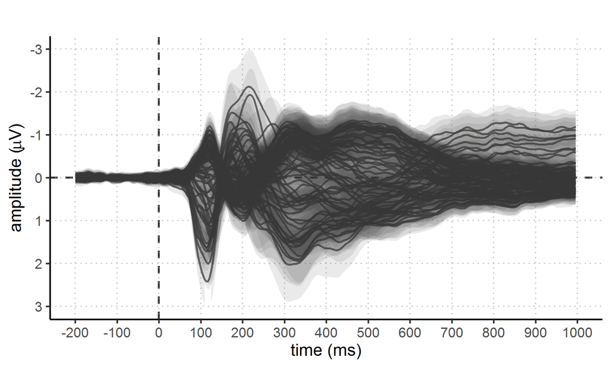

Butterfly plot

Prepare data for:

- topographies
- waveforms
- (RDI plots) pirateplots

### P1

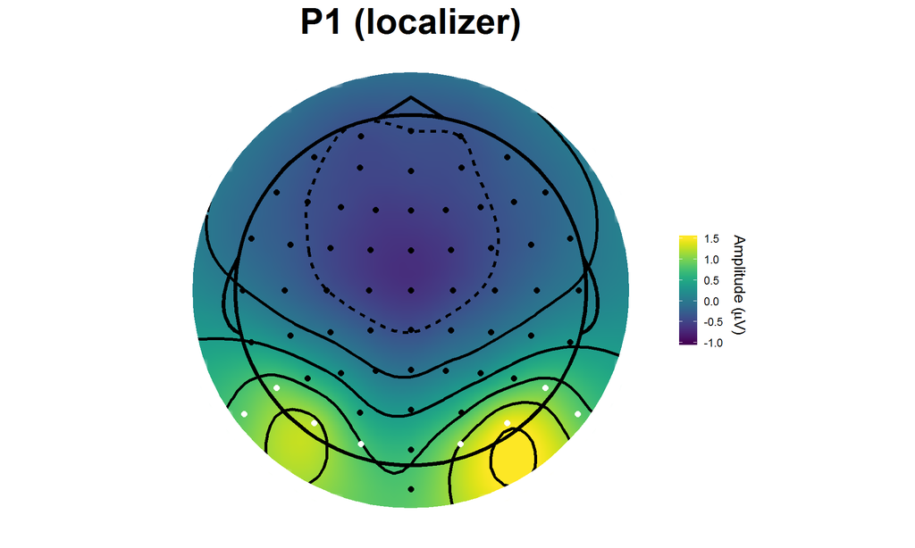

Amplitude extracted from the following electrode cluster: P7 P9 PO7 O1 O2 PO8 P8 P10.

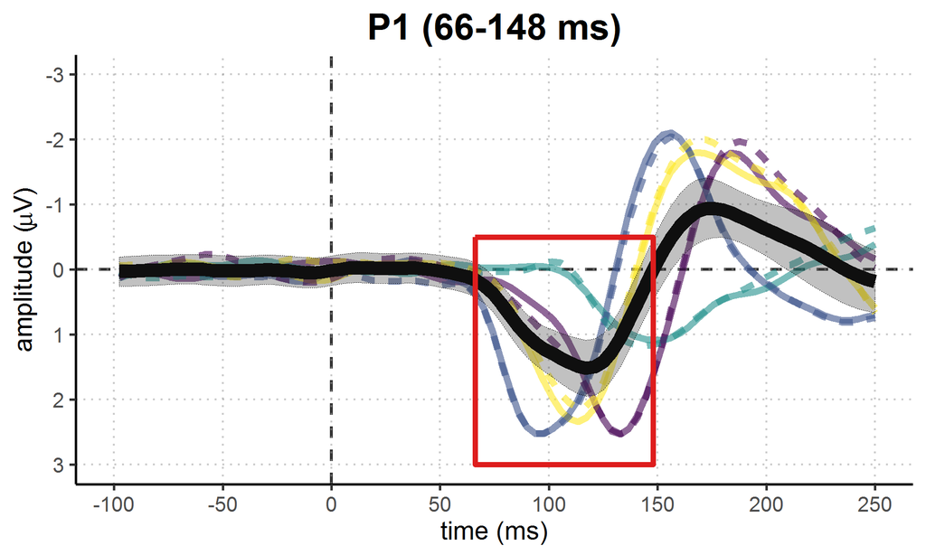

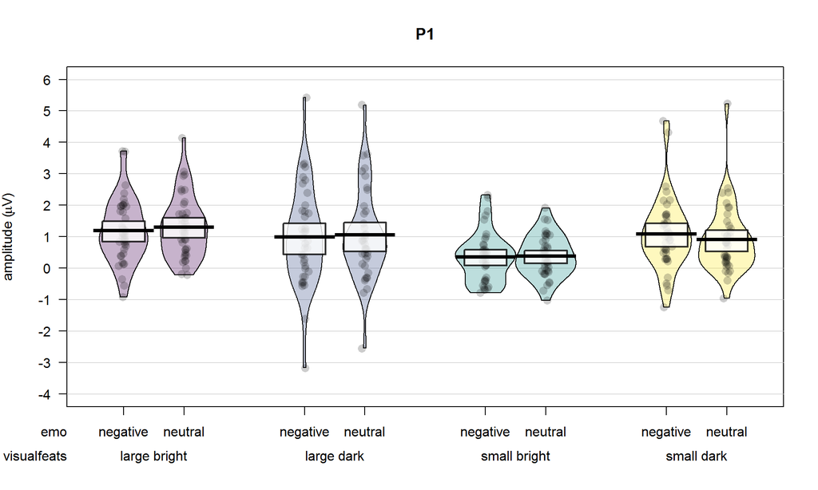

### N1

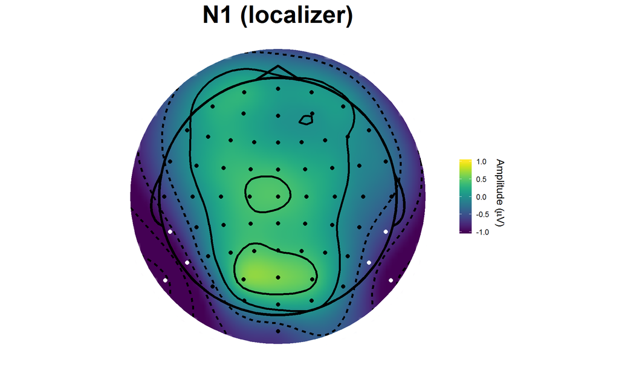

Amplitude extracted from the following electrode cluster: TP7 P7 P9 TP8 P8 P10.

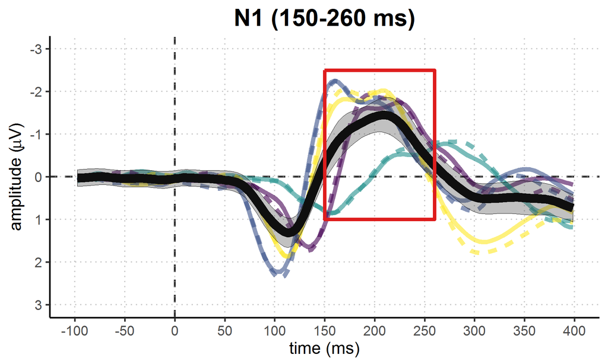

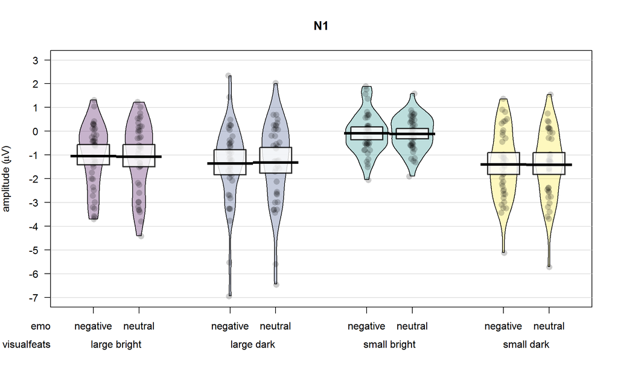

### EPN

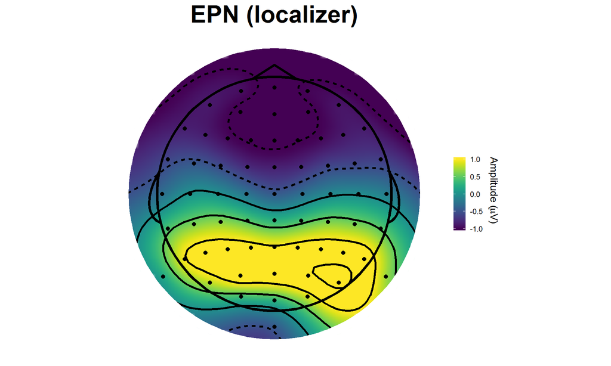

Because the topography differs from the classical EPN topography published in the literature, we identified this component by calculating the difference between negative and neutral conditions (averaged across size and contrast). This is in accordance with our pre-registered protocol.

Note that this was not necessary when identifying the LPP.

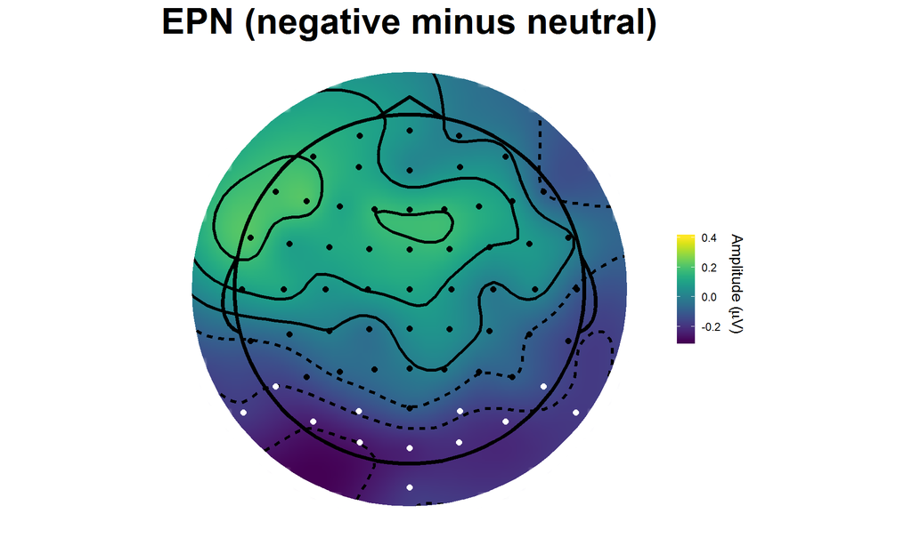

Amplitude extracted from the following electrode cluster: P7 P9 PO7 PO3 O1 Oz Iz O2 PO4 PO8 P8 P10.

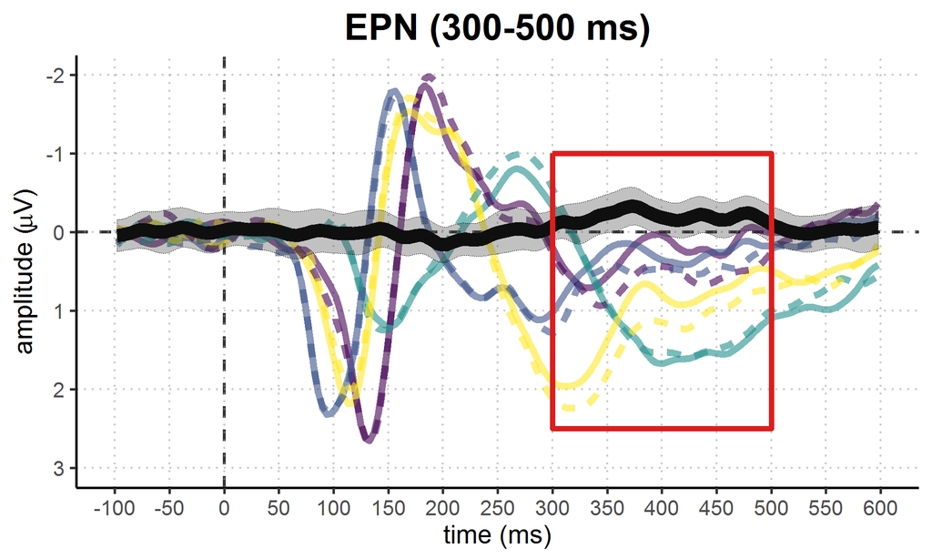

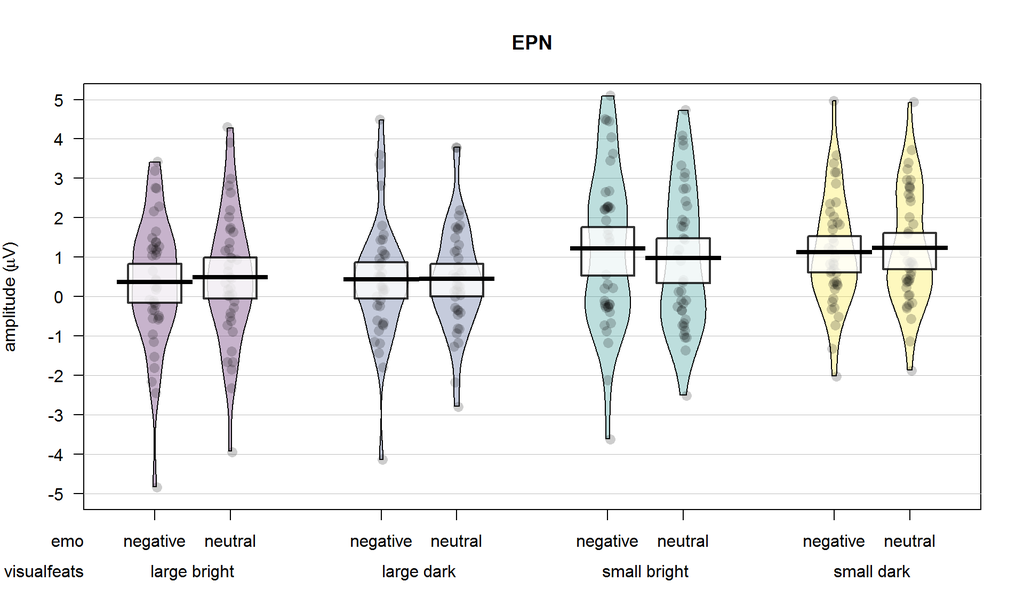

### LPP

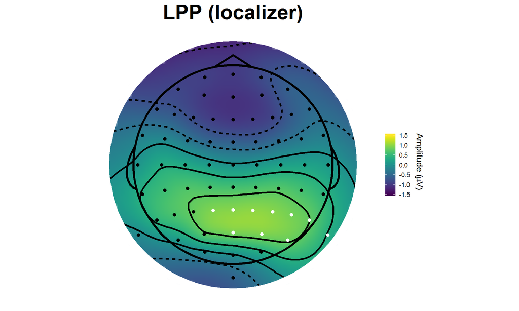

Amplitude extracted from the following electrode cluster: P1 Pz P2 P4 P6 P8 P10 POz PO4 PO8.

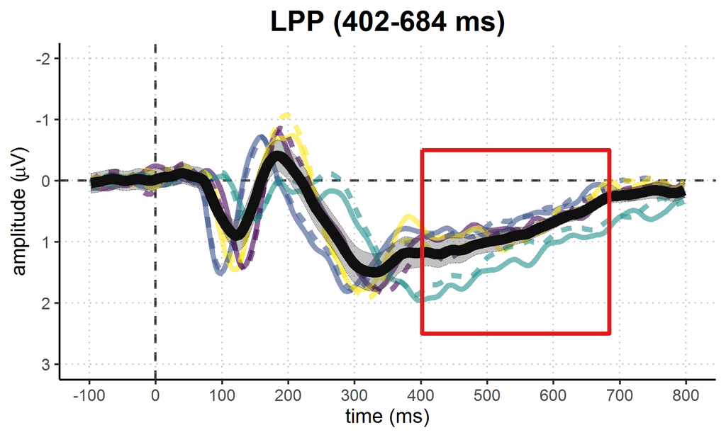

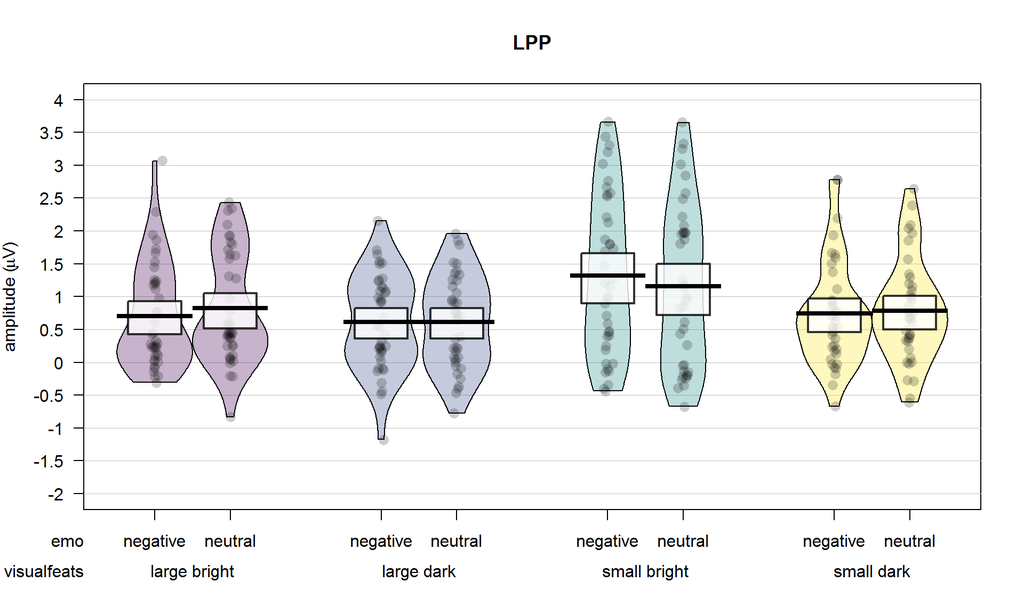

# CONFIRMATORY ANALYSIS

Calculate and compare the Bayes Factor of different linear mixed-effects models. Participants’ ID is included as random factor and its variance set as nuisance.

Compare (against the null model) the following models:

1. main effects of size and emotion
2. interactive effects of size and emotion
3. main effects of contrast and emotion
4. interactive effects of contrast and emotion
5. main effects of size, contrast, and emotion
6. interactive effects of size, contrast, and emotion

Afterwards, compare the best competing models to understand which one should be preferred overall.

## P1

| size | cont | emo | N | P1 | sd | se | ci |
| --- | --- | --- | --- | --- | --- | --- | --- |
| large | dark | negative | 2374 | 1.00 | 3.82 | 0.08 | 0.15 |
| large | dark | neutral | 2369 | 1.06 | 3.76 | 0.08 | 0.15 |
| large | bright | negative | 2373 | 1.21 | 3.76 | 0.08 | 0.15 |
| large | bright | neutral | 2364 | 1.34 | 3.76 | 0.08 | 0.15 |
| small | dark | negative | 2383 | 1.09 | 3.81 | 0.08 | 0.15 |
| small | dark | neutral | 2376 | 0.92 | 3.73 | 0.08 | 0.15 |
| small | bright | negative | 2365 | 0.34 | 3.83 | 0.08 | 0.15 |
| small | bright | neutral | 2363 | 0.38 | 3.86 | 0.08 | 0.16 |

|  | model | nar | nar.p.err | med | med.p.err | wid | wid.p.err |
| --- | --- | --- | --- | --- | --- | --- | --- |
| 6 | size x cont x emo | 517.255 | 26.1000 | 514.571 | 21.7573 | 512.823 | 38.5858 |
| 5 | size + cont + emo | 491.609 | 12.2519 | 490.485 | 11.2746 | 489.703 | 12.9381 |
| 1 | size + emo | 488.037 | 10.9842 | 487.249 | 13.1497 | 486.481 | 15.1375 |
| 2 | size x emo | 485.307 | 13.6379 | 484.258 | 13.9981 | 483.268 | 14.7865 |
| 3 | contr + emo | 455.182 | 10.5220 | 454.540 | 10.8545 | 453.442 | 11.0087 |
| 4 | cont x emo | 451.902 | 11.8637 | 451.118 | 15.3438 | 450.063 | 17.3036 |

When using a JZS prior with scaling factor *r* = 0.707 placed on standardized effect sizes, the model size x cont x emo ought to be preferred.  
The best model (size x cont x emo) explains the observed data 2.88605e+10 times better than the second best model (size + cont + emo).

### Paired comparisons

| comparison | nar | nar.p.err | med | med.p.err | wid | wid.p.err |
| --- | --- | --- | --- | --- | --- | --- |
| large.dark.negVSneut | -1.242476 | 0.000005 | -1.536763 | 0.000008 | -1.852970 | 0.000009 |
| small.dark.negVSneut | -0.083050 | 0.000004 | -0.305802 | 0.000002 | -0.575117 | 0.000001 |
| large.bright.negVSneut | -0.797664 | 0.000005 | -1.063337 | 0.000005 | -1.361115 | 0.000004 |
| small.bright.negVSneut | -1.410897 | 0.000005 | -1.716419 | 0.000010 | -2.039751 | 0.000011 |

Follow-up contrasts reveal that the effect of *emotion* does *not* explain changes in P1 amplitude:

- large size, high contrast: 0.215076;
- small size, high contrast: 0.736532;
- large size, low contrast: 0.345302;
- small size, low contrast: 0.179709.

### Exploratory model selection

|  | omit.from.full.model | nar | nar.p.err | med | med.p.err | wid | wid.p.err |
| --- | --- | --- | --- | --- | --- | --- | --- |
| 5 | emo | 4.09329 | 36.0755 | 4.41052 | 42.6639 | 4.95067 | 31.3857 |
| 1 | cont:emo:size | 3.43728 | 38.4878 | 3.57083 | 43.8103 | 3.94230 | 28.7947 |
| 3 | emo:size | 2.48143 | 34.5452 | 3.19101 | 41.8558 | 3.41415 | 37.5783 |
| 2 | cont:emo | 2.73721 | 40.2917 | 3.06986 | 44.1842 | 3.04649 | 29.1187 |
| 6 | cont | -4.06210 | 32.3345 | -3.74539 | 43.2791 | -2.49879 | 43.7396 |
| 4 | cont:size | -33.98743 | 31.3300 | -33.51031 | 47.4286 | -33.16676 | 31.6302 |
| 7 | size | -37.28107 | 33.3183 | -36.82423 | 42.7124 | -36.06912 | 40.7197 |

## N1

| size | cont | emo | N | N1 | sd | se | ci |
| --- | --- | --- | --- | --- | --- | --- | --- |
| large | dark | negative | 2374 | -1.36 | 3.67 | 0.08 | 0.15 |
| large | dark | neutral | 2369 | -1.38 | 3.69 | 0.08 | 0.15 |
| large | bright | negative | 2373 | -1.03 | 3.69 | 0.08 | 0.15 |
| large | bright | neutral | 2364 | -1.13 | 3.76 | 0.08 | 0.15 |
| small | dark | negative | 2383 | -1.39 | 3.67 | 0.08 | 0.15 |
| small | dark | neutral | 2376 | -1.45 | 3.71 | 0.08 | 0.15 |
| small | bright | negative | 2365 | -0.03 | 3.73 | 0.08 | 0.15 |
| small | bright | neutral | 2363 | -0.09 | 3.86 | 0.08 | 0.16 |

|  | model | nar | nar.p.err | med | med.p.err | wid | wid.p.err |
| --- | --- | --- | --- | --- | --- | --- | --- |
| 6 | size x cont x emo | 1136.056 | 17.41160 | 1133.451 | 7.68344 | 1130.967 | 7.70243 |
| 5 | size + cont + emo | 1095.332 | 3.83629 | 1094.308 | 3.88514 | 1093.332 | 3.86118 |
| 3 | contr + emo | 1054.636 | 3.27910 | 1053.986 | 3.46624 | 1053.302 | 3.31999 |
| 4 | cont x emo | 1050.900 | 4.20453 | 1049.967 | 4.21344 | 1048.949 | 4.57092 |
| 1 | size + emo | 968.697 | 3.55675 | 968.002 | 3.42639 | 967.291 | 3.45663 |
| 2 | size x emo | 964.942 | 4.22271 | 963.884 | 4.33880 | 962.799 | 4.42689 |

When using a JZS prior with scaling factor *r* = 0.707 placed on standardized effect sizes, the model size x cont x emo ought to be preferred.  
The best model (size x cont x emo) explains the observed data 9.98622e+16 times better than the second best model (size + cont + emo).

### Paired comparisons

| comparison | nar | nar.p.err | med | med.p.err | wid | wid.p.err |
| --- | --- | --- | --- | --- | --- | --- |
| large.dark.negVSneut | -1.44404 | 0.000005 | -1.75180 | 0.000010 | -2.07655 | 0.000012 |
| small.dark.negVSneut | -1.34226 | 0.000005 | -1.64318 | 0.000009 | -1.96359 | 0.000010 |
| large.bright.negVSneut | -1.04391 | 0.000005 | -1.32523 | 0.000006 | -1.63315 | 0.000006 |
| small.bright.negVSneut | -1.30534 | 0.000005 | -1.60379 | 0.000009 | -1.92265 | 0.000010 |

Follow-up contrasts reveal that the effect of *emotion* does *not* explain changes in N1 amplitude:

- large size, high contrast: 0.173461;
- small size, high contrast: 0.193365;
- large size, low contrast: 0.265741;
- small size, low contrast: 0.201133.

### Exploratory model selection

|  | omit.from.full.model | nar | nar.p.err | med | med.p.err | wid | wid.p.err |
| --- | --- | --- | --- | --- | --- | --- | --- |
| 2 | cont:emo | 3.73029 | 11.3004 | 4.21092 | 10.08546 | 4.41023 | 12.1467 |
| 3 | emo:size | 3.78233 | 10.9273 | 4.13584 | 9.92758 | 4.57307 | 22.7891 |
| 1 | cont:emo:size | 3.36395 | 13.3007 | 3.99916 | 9.90268 | 3.98102 | 11.7952 |
| 5 | emo | 3.34794 | 10.9888 | 3.81375 | 9.08760 | 4.15928 | 13.2988 |
| 7 | size | -41.23282 | 11.4377 | -40.69160 | 10.02464 | -40.54603 | 12.5904 |
| 4 | cont:size | -51.11622 | 12.8625 | -50.84828 | 10.26856 | -50.72175 | 12.5625 |
| 6 | cont | -127.35049 | 11.2607 | -126.85935 | 10.05205 | -126.72689 | 12.1201 |

Exploratory analyses further suggest that omitting *contrast x emotion* from the full model improves fitting by 67.418689 times. Removing *size x emotion*, *size x contrast x emotion*, and *emotion* also improves fitting by 62.541803, 54.552148, and 45.320135 times, respectively.  
Conversely, omitting the factor *size* or the *contrast x size* interaction lowers the explanatory value of the resulting model by 4.70043e+17 and 1.21095e+22 times. Finally, omitting the factor *contrast* is maximally detrimental, as it would lower the explanatory value of the resulting model by 1.24255e+55 times.

## EPN

| size | cont | emo | N | EPN | sd | se | ci |
| --- | --- | --- | --- | --- | --- | --- | --- |
| large | dark | negative | 2374 | 0.33 | 3.81 | 0.08 | 0.15 |
| large | dark | neutral | 2369 | 0.53 | 3.75 | 0.08 | 0.15 |
| large | bright | negative | 2373 | 0.27 | 3.93 | 0.08 | 0.16 |
| large | bright | neutral | 2364 | 0.58 | 3.88 | 0.08 | 0.16 |
| small | dark | negative | 2383 | 1.04 | 3.86 | 0.08 | 0.16 |
| small | dark | neutral | 2376 | 1.37 | 3.84 | 0.08 | 0.15 |
| small | bright | negative | 2365 | 1.15 | 4.01 | 0.08 | 0.16 |
| small | bright | neutral | 2363 | 1.09 | 4.11 | 0.08 | 0.17 |

|  | model | nar | nar.p.err | med | med.p.err | wid | wid.p.err |
| --- | --- | --- | --- | --- | --- | --- | --- |
| 1 | size + emo | 1326.56 | 2.33078 | 1325.85 | 2.35941 | 1325.17 | 2.40269 |
| 2 | size x emo | 1323.40 | 3.03718 | 1322.38 | 3.07248 | 1321.31 | 3.03256 |
| 5 | size + cont + emo | 1322.78 | 2.97131 | 1321.78 | 3.00485 | 1320.75 | 2.96195 |
| 6 | size x cont x emo | 1312.82 | 5.83613 | 1310.22 | 6.11963 | 1307.83 | 7.52248 |
| 3 | contr + emo | 1232.28 | 2.47300 | 1231.57 | 2.39635 | 1230.90 | 2.61943 |
| 4 | cont x emo | 1229.30 | 3.26642 | 1228.28 | 2.95904 | 1227.24 | 3.12543 |

When using a JZS prior with scaling factor *r* = 0.707 placed on standardized effect sizes, the model size + emo ought to be preferred.  
The best model (size + emo) explains the observed data 32.135152 times better than the second best model (size x emo).

### Paired comparisons

| comparison | nar | nar.p.err | med | med.p.err | wid | wid.p.err |
| --- | --- | --- | --- | --- | --- | --- |
| large.dark.negVSneut | -0.400217 | 0.000004 | -0.641569 | 0.000003 | -0.923346 | 0.000002 |
| small.dark.negVSneut | 2.410784 | 0.000000 | 2.312172 | 0.000808 | 2.132030 | 0.000000 |
| large.bright.negVSneut | 1.811765 | 0.000114 | 1.686604 | 0.000000 | 1.486398 | 0.000000 |
| small.bright.negVSneut | -1.369311 | 0.000005 | -1.672038 | 0.000009 | -1.993603 | 0.000011 |

Follow-up contrasts reveal that *emotion* may explain changes in EPN amplitude when words are presented in *small* font and *high* contrast (10.096328), as well as *large* font and *low* contrast (5.40111).

### Exploratory model selection

|  | omit.from.full.model | nar | nar.p.err | med | med.p.err | wid | wid.p.err |
| --- | --- | --- | --- | --- | --- | --- | --- |
| 6 | cont | 3.815077 | 10.40594 | 4.15207 | 8.02922 | 4.51423 | 9.07887 |
| 4 | cont:size | 3.523761 | 9.78409 | 3.87474 | 8.62592 | 4.29893 | 9.24992 |
| 3 | emo:size | 3.164643 | 9.69580 | 3.64743 | 8.39965 | 3.90327 | 8.22668 |
| 2 | cont:emo | 2.914801 | 9.37364 | 3.44049 | 9.04084 | 3.69495 | 8.67710 |
| 1 | cont:emo:size | 0.582295 | 10.24173 | 0.82504 | 8.67547 | 1.27789 | 8.33506 |
| 5 | emo | -2.762963 | 9.96539 | -2.29181 | 8.86863 | -2.08569 | 9.36214 |
| 7 | size | -90.470105 | 10.29009 | -90.18709 | 8.16845 | -89.69494 | 9.36080 |

Exploratory analyses further suggest that omitting the factor *contrast* from the full model improves fitting by 63.565196 times. Removing *contrast x size*, *size x emotion*, *contrast x emotion*, and *size x contrast x emotion* also improves fitting by 48.170267, 38.376057, 31.202253, and 2.281972 times, respectively.  
Conversely, omitting the factor *emotion* lowers the explanatory value of the resulting model by 9.892823 times. Finally, omitting the factor *size* is maximally detrimental, as it would lower the explanatory value of the resulting model by 1.47149e+39 times.

## LPP

| size | cont | emo | N | LPP | sd | se | ci |
| --- | --- | --- | --- | --- | --- | --- | --- |
| large | dark | negative | 2374 | 0.61 | 3.04 | 0.06 | 0.12 |
| large | dark | neutral | 2369 | 0.60 | 2.95 | 0.06 | 0.12 |
| large | bright | negative | 2373 | 0.71 | 3.03 | 0.06 | 0.12 |
| large | bright | neutral | 2364 | 0.81 | 3.04 | 0.06 | 0.12 |
| small | dark | negative | 2383 | 0.76 | 3.09 | 0.06 | 0.12 |
| small | dark | neutral | 2376 | 0.79 | 3.09 | 0.06 | 0.12 |
| small | bright | negative | 2365 | 1.35 | 3.31 | 0.07 | 0.13 |
| small | bright | neutral | 2363 | 1.17 | 3.36 | 0.07 | 0.14 |

|  | model | nar | nar.p.err | med | med.p.err | wid | wid.p.err |
| --- | --- | --- | --- | --- | --- | --- | --- |
| 5 | size + cont + emo | 520.745 | 11.57535 | 519.615 | 14.2100 | 518.566 | 12.2682 |
| 6 | size x cont x emo | 515.666 | 15.47449 | 513.487 | 15.6176 | 511.299 | 26.8897 |
| 1 | size + emo | 496.259 | 10.64948 | 495.588 | 11.4709 | 493.469 | Inf |
| 3 | contr + emo | 494.063 | 9.84944 | 493.603 | 11.7389 | 492.967 | 10.9007 |
| 2 | size x emo | 493.138 | 12.55091 | 492.071 | 10.0108 | 491.392 | 12.8547 |
| 4 | cont x emo | 490.484 | 12.06636 | 489.491 | 11.9940 | 488.629 | 15.2152 |

When using a JZS prior with scaling factor *r* = 0.707 placed on standardized effect sizes, the model size + cont + emo ought to be preferred.  
The best model (size + cont + emo) explains the observed data 458.581246 times better than the second best model (size x cont x emo).

### Paired comparisons

| comparison | nar | nar.p.err | med | med.p.err | wid | wid.p.err |
| --- | --- | --- | --- | --- | --- | --- |
| large.dark.negVSneut | -1.458985 | 0.000005 | -1.767756 | 0.000010 | -2.093136 | 0.000012 |
| small.dark.negVSneut | -1.388719 | 0.000005 | -1.692748 | 0.000009 | -2.015137 | 0.000011 |
| large.bright.negVSneut | -0.908117 | 0.000005 | -1.180755 | 0.000005 | -1.483057 | 0.000005 |
| small.bright.negVSneut | -0.007331 | 0.000003 | -0.225745 | 0.000001 | -0.492124 | 0.000001 |

Follow-up contrasts reveal that the effect of *emotion* does *not* explain changes in LPP amplitude:

- large size, high contrast: 0.170716;
- small size, high contrast: 0.184013;
- large size, low contrast: 0.307047;
- small size, low contrast: 0.797921.

### Exploratory model selection

|  | omit.from.full.model | nar | nar.p.err | med | med.p.err | wid | wid.p.err |
| --- | --- | --- | --- | --- | --- | --- | --- |
| 5 | emo | 4.28172 | 32.4270 | 3.86846 | 37.8228 | 4.55780 | 37.3126 |
| 2 | cont:emo | 3.20966 | 29.6824 | 3.36754 | 39.0607 | 3.86032 | 36.8418 |
| 3 | emo:size | 2.73710 | 31.1628 | 3.17247 | 41.5136 | 3.46928 | 31.2140 |
| 1 | cont:emo:size | 1.33654 | 29.1501 | 1.73832 | 38.0656 | 2.43893 | 31.2947 |
| 4 | cont:size | -3.64598 | 33.9532 | -4.02538 | 40.1684 | -3.28635 | 28.9564 |
| 6 | cont | -24.35056 | 30.2106 | -24.21533 | 39.7950 | -23.69823 | 34.9051 |
| 7 | size | -26.55092 | 30.2527 | -26.39286 | 40.6786 | -26.32859 | 30.1203 |

Exploratory analyses further suggest that omitting the factor *emotion* from the full model improves fitting by 47.868495 times. Removing *contrast x emotion*, *size x emotion*, and *size x contrast x emotion* also improves fitting by 29.007025, 23.866326, 5.687785 times, respectively.  
Conversely, omitting the *contrast x size* interaction or the factor *contrast* lowers the explanatory value of the resulting model by 56.001319 and 3.28538e+10 times, respectively. Finally, omitting the factor *size* is maximally detrimental, as it would lower the explanatory value of the resulting model by 2.89916e+11 times.

# SUPPLEMENTARY ANALYSIS

Visual inspection of the waveforms revealed unexpected latency shifts at the level of P1 and N1 components. This could be a potential source of noise when analyzing mean amplitude values. Therefore, we ran the same analyses as above but using, as dependent variables, peak amplitude and latency values of P1 and N1.

## P1

### Peak amplitude

Peak amplitude: positive value larger than the 3 points (~10 ms at 256 Hz sampling rate) on either side of the peak.  
Time window: 66-148 ms post-stimulus onset.  
Electrode cluster: P7 P9 PO7 O1 O2 PO8 P8 P10.

| size | cont | emo | visualfeats | N | value | sd | se | ci |
| --- | --- | --- | --- | --- | --- | --- | --- | --- |
| large | dark | negative | large dark | 40 | 3.29277 | 1.064229 | 0.168269 | 0.340357 |
| large | dark | neutral | large dark | 40 | 3.35137 | 1.025301 | 0.162114 | 0.327907 |
| large | bright | negative | large bright | 40 | 3.13585 | 0.873157 | 0.138058 | 0.279249 |
| large | bright | neutral | large bright | 40 | 3.00358 | 0.940474 | 0.148702 | 0.300778 |
| small | dark | negative | small dark | 40 | 2.90865 | 0.833393 | 0.131771 | 0.266532 |
| small | dark | neutral | small dark | 40 | 2.66942 | 0.941481 | 0.148861 | 0.301100 |
| small | bright | negative | small bright | 40 | 1.46732 | 1.222649 | 0.193318 | 0.391022 |
| small | bright | neutral | small bright | 40 | 1.29638 | 1.664701 | 0.263212 | 0.532397 |

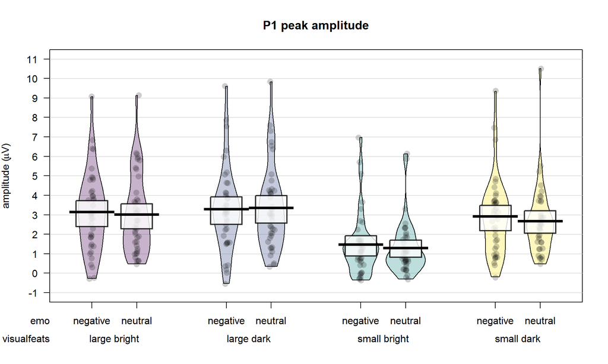

|  | model | nar | nar.p.err | med | med.p.err | wid | wid.p.err |
| --- | --- | --- | --- | --- | --- | --- | --- |
| 6 | size x cont x emo | 113.0706 | 2.094634 | 111.7211 | 2.209905 | 109.9923 | 2.501647 |
| 5 | size + cont + emo | 110.3997 | 0.971393 | 110.0348 | 0.997633 | 109.4453 | 1.069703 |
| 1 | size + emo | 94.8927 | 0.865454 | 94.5728 | 0.873548 | 94.1258 | 0.893395 |
| 2 | size x emo | 93.2774 | 1.091705 | 92.6571 | 1.102690 | 91.8616 | 1.163089 |
| 3 | contr + emo | 82.2860 | 0.857190 | 81.8535 | 0.884951 | 81.2898 | 0.934487 |
| 4 | cont x emo | 80.5308 | 1.058112 | 79.7609 | 1.122411 | 78.9086 | 1.178153 |

When using a JZS prior with scaling factor *r* = 0.707 placed on standardized effect sizes, the model size x cont x emo ought to be preferred.  
The best model (size x cont x emo) explains the observed data 5.399618 times better than the second best model (size + cont + emo).

### Paired comparisons

| comparison | nar | nar.p.err | med | med.p.err | wid | wid.p.err |
| --- | --- | --- | --- | --- | --- | --- |
| large.dark.negVSneut | -1.32816 | 0.000005 | -1.628132 | 0.000009 | -1.947953 | 0.000010 |
| small.dark.negVSneut | -0.07760 | 0.000004 | -0.300039 | 0.000002 | -0.569142 | 0.000001 |
| large.bright.negVSneut | -1.22201 | 0.000005 | -1.514945 | 0.000008 | -1.830291 | 0.000008 |
| small.bright.negVSneut | -1.19346 | 0.000005 | -1.484519 | 0.000008 | -1.798667 | 0.000008 |

Follow-up contrasts reveal that the effect of *emotion* does *not* explain changes in P1 peak amplitude:

- large size, high contrast: 0.196296;
- small size, high contrast: 0.74079;
- large size, low contrast: 0.21982;
- small size, low contrast: 0.226611.

### Exploratory model selection

|  | omit.from.full.model | nar | nar.p.err | med | med.p.err | wid | wid.p.err |
| --- | --- | --- | --- | --- | --- | --- | --- |
| 2 | cont:emo | 1.73619 | 2.56296 | 2.04763 | 2.88572 | 2.39096 | 3.39052 |
| 5 | emo | 1.67476 | 2.53086 | 1.96165 | 2.85731 | 2.31218 | 3.33662 |
| 3 | emo:size | 1.57700 | 2.57855 | 1.88649 | 2.86778 | 2.19664 | 3.27840 |
| 1 | cont:emo:size | 1.35671 | 2.56817 | 1.63647 | 2.86677 | 1.98664 | 3.32111 |
| 4 | cont:size | -7.31691 | 2.68639 | -7.31532 | 2.96159 | -7.18641 | 3.42045 |
| 6 | cont | -16.71162 | 2.66695 | -16.67648 | 3.09197 | -16.55558 | 3.41316 |
| 7 | size | -30.00663 | 2.70211 | -30.19997 | 2.92623 | -30.15620 | 3.36965 |

Exploratory analyses suggest that omitting *contrast x emotion* from the full model improves fitting by 7.749527 times. Removing *emotion*, *size x emotion*, and *size x contrast x emotion* also improves fitting by 7.111038, 6.59615, and 5.137032 times, respectively.  
Conversely, omitting *contrast x size* or *contrast* lowers the explanatory value of the resulting model by 1503.160419 and 1.74785e+07 times, respectively. Finally, omitting the factor *size* is maximally detrimental, as it would lower the explanatory value of the resulting model by 1.30521e+13 times.

### Peak latency

Peak latency: time (in ms) of the positive value larger than the 3 points (~10 ms at 256 Hz sampling rate) on either side of the peak.  
Time window: 66-148 ms post-stimulus onset.  
Electrode cluster: P7 P9 PO7 O1 O2 PO8 P8 P10.

| size | cont | emo | visualfeats | N | value | sd | se | ci |
| --- | --- | --- | --- | --- | --- | --- | --- | --- |
| large | dark | negative | large dark | 40 | 102.344 | 15.28566 | 2.41687 | 4.88859 |
| large | dark | neutral | large dark | 40 | 103.711 | 13.59364 | 2.14934 | 4.34746 |
| large | bright | negative | large bright | 40 | 126.270 | 17.38954 | 2.74953 | 5.56145 |
| large | bright | neutral | large bright | 40 | 123.633 | 21.13074 | 3.34106 | 6.75794 |
| small | dark | negative | small dark | 40 | 116.699 | 13.39870 | 2.11852 | 4.28511 |
| small | dark | neutral | small dark | 40 | 113.184 | 9.92574 | 1.56940 | 3.17441 |
| small | bright | negative | small bright | 40 | 116.992 | 22.47403 | 3.55346 | 7.18754 |
| small | bright | neutral | small bright | 40 | 115.430 | 27.00762 | 4.27028 | 8.63745 |

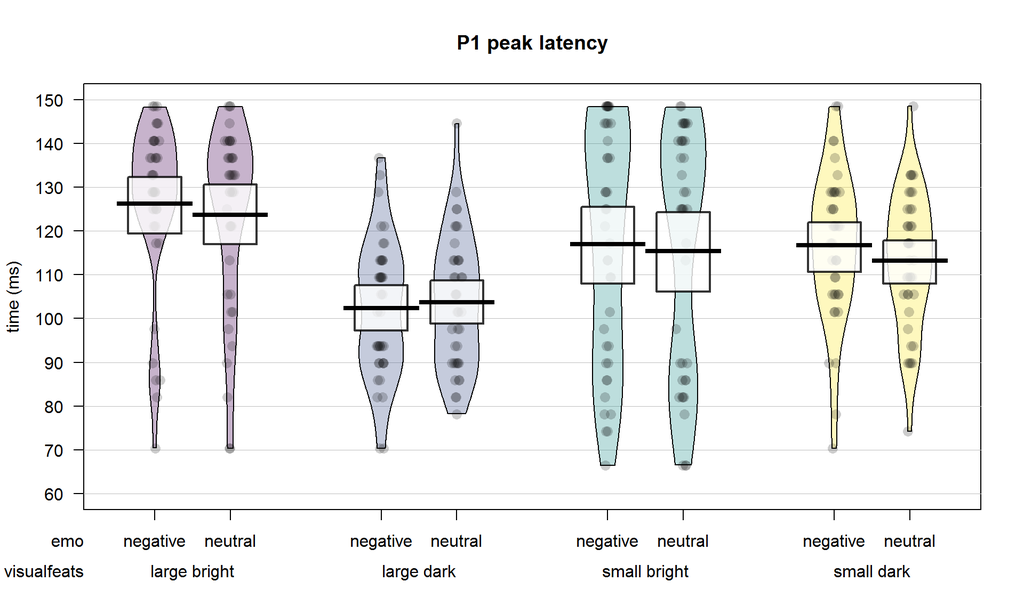

|  | model | nar | nar.p.err | med | med.p.err | wid | wid.p.err |
| --- | --- | --- | --- | --- | --- | --- | --- |
| 6 | size x cont x emo | 10.49207 | 4.43463 | 8.66200 | 4.73642 | 6.62556 | 4.12796 |
| 3 | contr + emo | 7.81885 | 1.88321 | 7.36593 | 1.98286 | 6.86110 | 2.07785 |
| 4 | cont x emo | 6.11854 | 2.30846 | 5.32697 | 2.38890 | 4.45200 | 2.67473 |
| 5 | size + cont + emo | 5.96262 | 2.27790 | 5.27892 | 2.43849 | 4.37852 | 2.50801 |
| 1 | size + emo | -4.88178 | 2.43625 | -5.48894 | 2.49392 | -6.15739 | 2.52529 |
| 2 | size x emo | -6.55577 | 2.87838 | -7.51581 | 2.98269 | -8.51849 | 3.22038 |

When using a JZS prior with scaling factor *r* = 0.707 placed on standardized effect sizes, the model size x cont x emo ought to be preferred.  
The best model (size x cont x emo) explains the observed data 3.654901 times better than the second best model (contr + emo).

### Paired comparisons

| comparison | nar | nar.p.err | med | med.p.err | wid | wid.p.err |
| --- | --- | --- | --- | --- | --- | --- |
| large.dark.negVSneut | -1.324323 | 0.000005 | -1.624043 | 0.000009 | -1.943702 | 0.000010 |
| small.dark.negVSneut | -0.436943 | 0.000004 | -0.680494 | 0.000003 | -0.963732 | 0.000002 |
| large.bright.negVSneut | -1.288675 | 0.000005 | -1.586022 | 0.000008 | -1.904176 | 0.000009 |
| small.bright.negVSneut | -1.432421 | 0.000005 | -1.739395 | 0.000010 | -2.063643 | 0.000012 |

Follow-up contrasts reveal that the effect of *emotion* does *not* explain changes in P1 peak latency:

- large size, high contrast: 0.1971;
- small size, high contrast: 0.506367;
- large size, low contrast: 0.204738;
- small size, low contrast: 0.175627.

### Exploratory model selection

|  | omit.from.full.model | nar | nar.p.err | med | med.p.err | wid | wid.p.err |
| --- | --- | --- | --- | --- | --- | --- | --- |
| 5 | emo | 1.80232 | 5.20346 | 2.20643 | 5.41233 | 2.45613 | 6.60289 |
| 7 | size | 1.84326 | 5.39822 | 2.17037 | 5.14028 | 2.36546 | 6.52249 |
| 2 | cont:emo | 1.74926 | 5.45687 | 2.06235 | 5.31932 | 2.28293 | 6.55308 |
| 3 | emo:size | 1.69224 | 5.33400 | 1.98294 | 5.22328 | 2.22946 | 6.55180 |
| 1 | cont:emo:size | 1.16775 | 5.35314 | 1.53589 | 5.51573 | 1.82627 | 6.55557 |
| 4 | cont:size | -9.11302 | 6.10315 | -9.03383 | 6.28059 | -9.00566 | 7.21239 |
| 6 | cont | -11.81129 | 5.63718 | -11.66109 | 6.02184 | -11.60288 | 6.93401 |

Exploratory analyses suggest that omitting *emotion* from the full model improves fitting by 9.083263 times. Removing *size*, *contrast x emotion*, *size x emotion*, and *size x contrast x emotion* also improves fitting by 8.761524, 7.864414, 7.264101, and 4.645467 times, respectively.  
Conversely, omitting *contrast x size* lowers the explanatory value of the resulting model by 8381.862696 times. Finally, omitting the factor *contrast* is maximally detrimental, as it would lower the explanatory value of the resulting model by 1.15971e+05 times.

## N1

### Peak amplitude

Peak amplitude: negative value larger than the 3 points (~10 ms at 256 Hz sampling rate) on either side of the peak.  
Time window: 150-260 ms post-stimulus onset.  
Electrode cluster: TP7 P7 P9 TP8 P8 P10.

| size | cont | emo | visualfeats | N | value | sd | se | ci |
| --- | --- | --- | --- | --- | --- | --- | --- | --- |
| large | dark | negative | large dark | 40 | -3.506750 | 1.046491 | 0.165465 | 0.334684 |
| large | dark | neutral | large dark | 40 | -3.497500 | 1.130311 | 0.178718 | 0.361491 |
| large | bright | negative | large bright | 40 | -3.067950 | 0.711714 | 0.112532 | 0.227617 |
| large | bright | neutral | large bright | 40 | -3.051325 | 0.835515 | 0.132107 | 0.267211 |
| small | dark | negative | small dark | 40 | -3.243100 | 0.881943 | 0.139447 | 0.282059 |
| small | dark | neutral | small dark | 40 | -3.302025 | 1.089445 | 0.172256 | 0.348421 |
| small | bright | negative | small bright | 40 | -0.992025 | 1.719284 | 0.271843 | 0.549854 |
| small | bright | neutral | small bright | 40 | -1.244675 | 1.309893 | 0.207112 | 0.418924 |

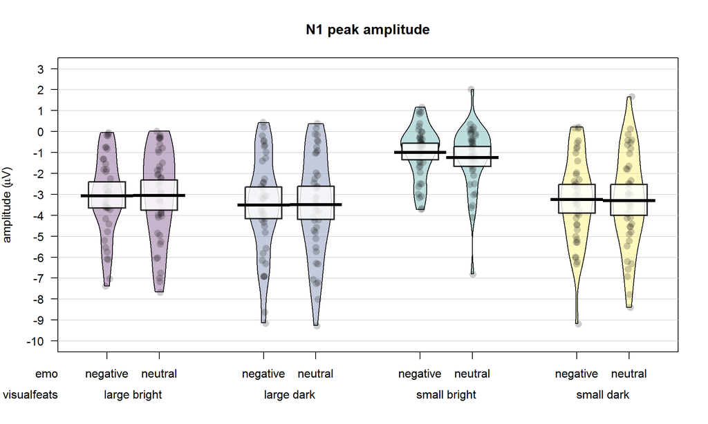

|  | model | nar | nar.p.err | med | med.p.err | wid | wid.p.err |
| --- | --- | --- | --- | --- | --- | --- | --- |
| 6 | size x cont x emo | 132.4703 | 2.241438 | 131.3619 | 2.199058 | 129.8780 | 2.341888 |
| 5 | size + cont + emo | 120.4948 | 1.016894 | 120.2019 | 1.004117 | 119.7244 | 1.043572 |
| 3 | contr + emo | 96.7358 | 0.880263 | 96.4408 | 0.869952 | 96.0163 | 0.905908 |
| 4 | cont x emo | 95.0261 | 1.089068 | 94.3718 | 1.091208 | 93.6290 | 1.139111 |
| 1 | size + emo | 86.8809 | 0.849904 | 86.4638 | 0.880800 | 85.9679 | 0.913615 |
| 2 | size x emo | 85.2156 | 1.055602 | 84.4947 | 1.108911 | 83.6982 | 1.181554 |

When using a JZS prior with scaling factor *r* = 0.707 placed on standardized effect sizes, the model size x cont x emo ought to be preferred.  
The best model (size x cont x emo) explains the observed data 7.02657e+04 times better than the second best model (size + cont + emo).

### Paired comparisons

| comparison | nar | nar.p.err | med | med.p.err | wid | wid.p.err |
| --- | --- | --- | --- | --- | --- | --- |
| large.dark.negVSneut | -1.45681 | 0.000005 | -1.76543 | 0.000010 | -2.09072 | 0.000012 |
| small.dark.negVSneut | -1.39664 | 0.000005 | -1.70120 | 0.000009 | -2.02393 | 0.000011 |
| large.bright.negVSneut | -1.45587 | 0.000005 | -1.76442 | 0.000010 | -2.08967 | 0.000012 |
| small.bright.negVSneut | -1.05302 | 0.000005 | -1.33493 | 0.000006 | -1.64322 | 0.000007 |

Follow-up contrasts reveal that the effect of *emotion* does *not* explain changes in N1 peak amplitude:

- large size, high contrast: 0.171113;
- small size, high contrast: 0.182464;
- large size, low contrast: 0.171285;
- small size, low contrast: 0.263177.

### Exploratory model selection

|  | omit.from.full.model | nar | nar.p.err | med | med.p.err | wid | wid.p.err |
| --- | --- | --- | --- | --- | --- | --- | --- |
| 5 | emo | 1.93682 | 2.83136 | 2.30938 | 2.68627 | 2.64839 | 2.94151 |
| 2 | cont:emo | 1.69299 | 2.83217 | 2.05149 | 2.69867 | 2.38868 | 2.93760 |
| 3 | emo:size | 1.58176 | 2.82807 | 1.91348 | 2.65988 | 2.28989 | 2.94905 |
| 1 | cont:emo:size | 1.36920 | 2.85534 | 1.72734 | 2.70176 | 2.04311 | 2.98017 |
| 4 | cont:size | -16.77897 | 2.88563 | -16.83048 | 2.80361 | -16.80421 | 2.99904 |
| 7 | size | -27.19351 | 2.98257 | -27.23941 | 2.83730 | -27.27558 | 3.00897 |
| 6 | cont | -38.20814 | 2.87918 | -38.39119 | 2.74688 | -38.44893 | 3.10646 |

Exploratory analyses suggest that omitting *emotion* from the full model improves fitting by 10.068159 times. Removing *contrast x emotion*, *size x emotion*, and *size x contrast x emotion* also improves fitting by 7.779449, 6.776614, and 5.62566 times, respectively.  
Conversely, omitting *contrast x size* or *size* lowers the explanatory value of the resulting model by 2.03884e+07 and 6.75966e+11 times, respectively. Finally, omitting the factor *contrast* is maximally detrimental, as it would lower the explanatory value of the resulting model by 4.71065e+16 times.

### Peak latency

Peak latency: time (in ms) of the negative value larger than the 3 points (~10 ms at 256 Hz sampling rate) on either side of the peak.  
Time window: 150-260 ms post-stimulus onset.  
Electrode cluster: TP7 P7 P9 TP8 P8 P10.

| size | cont | emo | visualfeats | N | value | sd | se | ci |
| --- | --- | --- | --- | --- | --- | --- | --- | --- |
| large | dark | negative | large dark | 40 | 190.235 | 23.3587 | 3.69333 | 7.47047 |
| large | dark | neutral | large dark | 40 | 187.793 | 19.4473 | 3.07488 | 6.21953 |
| large | bright | negative | large bright | 40 | 210.742 | 17.4317 | 2.75619 | 5.57492 |
| large | bright | neutral | large bright | 40 | 202.149 | 20.1355 | 3.18370 | 6.43963 |
| small | dark | negative | small dark | 40 | 196.484 | 17.4944 | 2.76611 | 5.59498 |
| small | dark | neutral | small dark | 40 | 199.316 | 21.2240 | 3.35581 | 6.78777 |
| small | bright | negative | small bright | 40 | 213.770 | 32.1088 | 5.07684 | 10.26888 |
| small | bright | neutral | small bright | 40 | 214.942 | 30.5002 | 4.82250 | 9.75444 |

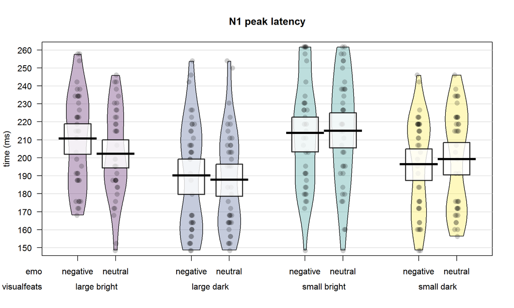

|  | model | nar | nar.p.err | med | med.p.err | wid | wid.p.err |
| --- | --- | --- | --- | --- | --- | --- | --- |
| 5 | size + cont + emo | 26.6374 | 1.15975 | 25.99402 | 1.23910 | 25.17737 | 1.32229 |
| 3 | contr + emo | 24.2389 | 1.01281 | 23.84373 | 1.04773 | 23.31152 | 1.10679 |
| 4 | cont x emo | 22.7115 | 1.25384 | 21.96359 | 1.31734 | 21.12494 | 1.36513 |
| 6 | size x cont x emo | 21.1145 | 2.63524 | 19.27057 | 2.95377 | 17.09435 | 3.03421 |
| 1 | size + emo | 11.0990 | 1.15088 | 10.52226 | 1.20173 | 9.90702 | 1.22307 |
| 2 | size x emo | 10.1075 | 1.38252 | 9.24141 | 1.45247 | 8.28288 | 1.55068 |

When using a JZS prior with scaling factor *r* = 0.707 placed on standardized effect sizes, the model size + cont + emo ought to be preferred.  
The best model (size + cont + emo) explains the observed data 8.587309 times better than the second best model (contr + emo).

### Paired comparisons

| comparison | nar | nar.p.err | med | med.p.err | wid | wid.p.err |
| --- | --- | --- | --- | --- | --- | --- |
| large.dark.negVSneut | -1.291370 | 0.000005 | -1.588896 | 0.000008 | -1.907163 | 0.000009 |
| small.dark.negVSneut | -1.210616 | 0.000005 | -1.502803 | 0.000008 | -1.817672 | 0.000008 |
| large.bright.negVSneut | 0.503694 | 0.000002 | 0.313551 | 0.000001 | 0.066594 | 0.000000 |
| small.bright.negVSneut | -1.445018 | 0.000005 | -1.752844 | 0.000010 | -2.077628 | 0.000012 |

Follow-up contrasts reveal that the effect of *emotion* does not explain changes in N1 peak latency:

- large size, high contrast: 0.204151;
- small size, high contrast: 0.222506;
- large size, low contrast: 1.368275;
- small size, low contrast: 0.173281.

### Exploratory model selection

|  | omit.from.full.model | nar | nar.p.err | med | med.p.err | wid | wid.p.err |
| --- | --- | --- | --- | --- | --- | --- | --- |
| 5 | emo | 1.931767 | 3.22020 | 2.22744 | 3.68240 | 2.52258 | 3.97049 |
| 4 | cont:size | 1.786055 | 3.22439 | 2.12057 | 3.88982 | 2.36282 | 3.92086 |
| 2 | cont:emo | 1.581175 | 3.24923 | 1.86391 | 3.70373 | 2.14456 | 3.96683 |
| 1 | cont:emo:size | 1.361681 | 3.19032 | 1.69462 | 3.68823 | 1.97532 | 3.97024 |
| 3 | emo:size | 0.884392 | 3.23736 | 1.17626 | 3.77075 | 1.44432 | 3.97676 |
| 7 | size | -2.390164 | 3.62316 | -2.18997 | 3.73756 | -1.91273 | 4.52846 |
| 6 | cont | -15.650214 | 3.70281 | -15.62619 | 4.03748 | -15.50851 | 4.38427 |

Exploratory analyses suggest that omitting *emotion* from the full model improves fitting by 9.276138 times. Removing *size x contrast*, *contrast x emotion*, *size x contrast x emotion*, and *size x emotion* also improves fitting by 8.3359, 6.44889, 5.444556, and 3.242228 times, respectively.  
Conversely, omitting *size* lowers the explanatory value of the resulting model by 8.934949 times. Finally, omitting the factor *contrast* is maximally detrimental, as it would lower the explanatory value of the resulting model by 6.11461e+06 times.